# Logos

jcb

12 septembre 2015

# Logos pour la cartographie

Dossier Trame_Commune/Logos

Les logos sont préférentiellement au format .png

source:

- ambulances: http://www.flaticon.com/free-icons/ambulance_225
- hélicos: http://www.flaticon.com/search/helicopters
- hospitals: http://www.flaticon.com/free-icon/hospital-buildings_33777
- SAMI, SDIS: http://www.flaticon.com/free-icon/male-telemarketer_81523
- déconta: http://www.flaticon.com/free-icon/man-showering_76657
- sang: http://www.flaticon.com/free-icon/blood-perfusion_69691

Licence: Icon made by [Freepick](http://www.flaticon.com/authors/freepik) from www.flaticon.com

Le dossier **Logos/data** contient un certain nombre d’images à difféents niveaux de résolution:

- ambulance15
- shopper5 (hélicoptère)
- hospital11
- man253 (douche mobile)
- men39 (douche fixe)
- perfusion
- transport51 (ambulance)

## Afficher une image PNG dans un graphe

[output not shown]

```
## [1] "array"
```

```r
dim(amb)
```

```
## [1] 64 64  4
```

L’objet **amb** est un tableau numérique de 64 lignes et 64 colonnes avec quatre couches (red, green, blue, alpha; short RGBA).

Let’s have a look at the first layer (red) and replace all non-zero entries by a one and the zeros by a dot. This will show us the pattern of non-zero values and we already see the contours.

```r
l4 <- amb[,,1]
l4[l4 > 0] <- 1
l4[l4 == 0] <- "."
d <- apply(l4, 1, function(x) {
 cat(paste0(x, collapse=""), "\n")
})
```

```
## ................................................................
## ................................................................
## ................................................................
## ................................................................
## ................................................................
## ................................................................
## ................................................................
## ................................................................
## ................................................................
## ................................................................
## ................................................................
## .....................11.........................................
## .....................11.........................................
## .....................11.........................................
## ...............111...11...11....................................
## ...............1111......111....................................
## ................111.111.111.....................................
## ....................1111........................................
## ....................1111........................................
## ....................1111........................................
## ................................................................
## ...............1111111111111111111111111111111111111111111111111
## .............111111111111111111111111111111111111111111111111111
## ............1111.......11111111111111111111111111111111111111111
## ...........11111.......11111111111111111111111111111111111111111
## ..........11111........11111111111111111111111111111111111111111
## ..........1111.........11111111111111111111111111111111111111111
## .........1111..........11111111111111111111.11111111111111111111
## ........1111...........11111111111111111111.11111111111111111111
## .......1111............11111111111111111111.11111111111111111111
## ......1111.............11111111111111111111.11111111111111111111
## ......111..............1111111111111111.........1111111111111111
## ....11111111111111111111111111111111111.........1111111111111111
## ...1111111111111111111111111111111111111111.11111111111111111111
## .111111111111111111111111111111111111111111.11111111111111111111
## 1111111111111111111111111111111111111111111.11111111111111111111
## 1111111111111111111111111111111111111111111.11111111111111111111
## 1111111111111111111111111111111111111111111111111111111111111111
## 1111111111111111111111111111111111111111111111111111111111111111
## 1111111111111111111111111111111111111111111111111111111111111111
```

[output cut: 9 more lines]

```
## .....11111111111..............................1111111111........
## ......111111111................................111111111........
## ......111111111................................11111111.........
## ........111111..................................111111..........
## ................................................................
## ................................................................
## ................................................................
## ................................................................
## ................................................................
## ................................................................
## ................................................................
## ................................................................
## ................................................................
## ................................................................
## ................................................................
```

To display the image in R one way is to raster the image (i.e. the RGBA layers are collapsed into a layer of single HEX value) and print it using rasterImage.

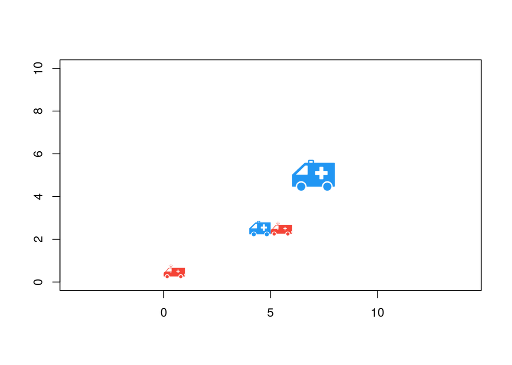

```r
rimg <- as.raster(amb) # raster multilayer object
r <- nrow(rimg) / ncol(rimg) # image ratio
plot(c(0,10), c(0,10), type = "n", xlab = "", ylab = "", asp=1) # une zone graphique vide
rasterImage(rimg, 0, 0, 1, r) # img, x1, y1, x2, y2
rasterImage(rimg, 5, 2, 6, 3)

smur <- as.raster(readPNG("data/ambulance15(14).png"))
rasterImage(smur, 4, 2, 5, 3)
rasterImage(smur, 6, 4, 8, 6)
```